# Conditional and latent trends

Distinguish unconditional, conditional, latent, and clustered trend assumptions.

The ATT-DML examples vary the information needed to make untreated trends comparable. Some use observed features, some use latent structure, and one adds clustered serial dependence.

The related public paper is [Augmented Balancing Estimators of the Average Treatment Effect on the Treated in Cross-Sectional and Panel Designs](https://apoorvalal.github.io/files/papers/augbal.pdf).

```python
import matplotlib.pyplot as plt
import numpy as np

from pypanelsim import designs

print(designs.available_att_dml_designs())
```

```
('conditional_parallel_trends', 'conditional_parallel_trends_nonlinear', 'latent_parallel', 'latent_nonparallel', 'clustered_arma')
```

## 1 Design map

| Variant | Information that restores comparability | Main failure when omitted |
| --- | --- | --- |
| `conditional_parallel_trends` | observed linear features | unconditional trends differ |
| `conditional_parallel_trends_nonlinear` | nonlinear functions of observed features | a linear nuisance model is misspecified |
| `latent_parallel` | stable latent structure | observed covariates are insufficient |
| `latent_nonparallel` | no stable latent comparison | latent parallel trends fails |
| `clustered_arma` | group trend and serial dependence structure | independent-error approximations fail |

The names describe the simulated data, not a guarantee that a given estimator identifies the ATT.

## 2 Conditional parallel trends

The conditional designs have two periods and high-dimensional unit features. Assignment uses a sparse feature index. Untreated trends use the same features.

```python
conditional_config = designs.ATTDMConditionalConfig(
    n_units=600,
    n_features=20,
    n_active=5,
    treatment_effect=3.0,
)

linear = designs.att_dml(
    "conditional_parallel_trends",
    config=conditional_config,
    seed=42,
)
nonlinear = designs.att_dml(
    "conditional_parallel_trends_nonlinear",
    config=conditional_config,
    seed=42,
)

print(linear.shape, nonlinear.shape)
print(linear.unit_covariate_names[:5])
print(round(linear.true_att, 3), round(nonlinear.true_att, 3))
```

```
(600, 2) (600, 2)
('x1', 'x2', 'x3', 'x4', 'x5')
3.015 2.98
```

The nonlinear variant uses transformed covariates to generate outcomes while estimators receive the raw features. It tests nonlinear adjustment without changing the ATT target.

## 3 Diagnose trend imbalance

For a two-period panel, each unit’s observed change is $\Delta Y_i=Y_{i1}-Y_{i0}$. Compare changes by treatment status before fitting an adjusted estimator.

```python
def change_gap(panel):
    changes = np.diff(panel.outcome, axis=1).ravel()
    treated = panel.ever_treated
    return float(changes[treated].mean() - changes[~treated].mean())

print("linear raw change gap:", round(change_gap(linear), 3))
print("nonlinear raw change gap:", round(change_gap(nonlinear), 3))
```

```
linear raw change gap: 3.033
nonlinear raw change gap: 3.339
```

The figure plots each unit’s outcome change against its first observed feature. The nonlinear design changes the conditional shape, not only the mean gap.

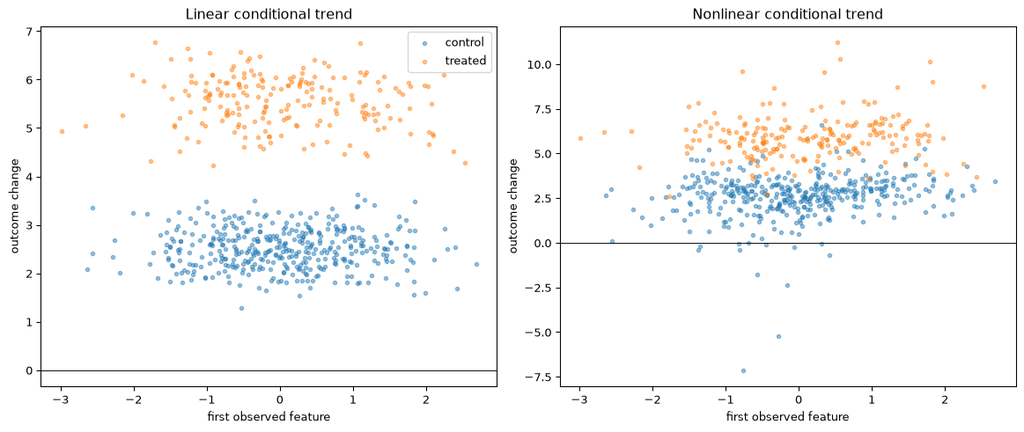

Figure 1: Observed feature-outcome-change relationships under linear and nonlinear conditional trends.

```python
figure, axes = plt.subplots(1, 2, figsize=(12, 5), constrained_layout=True)
for axis, (label, draw) in zip(
    axes,
    (("Linear conditional trend", linear), ("Nonlinear conditional trend", nonlinear)),
    strict=True,
):
    changes = np.diff(draw.outcome, axis=1).ravel()
    x1 = draw.unit_covariates[:, 0]
    axis.scatter(
        x1[~draw.ever_treated],
        changes[~draw.ever_treated],
        s=10,
        alpha=0.45,
        label="control",
    )
    axis.scatter(
        x1[draw.ever_treated],
        changes[draw.ever_treated],
        s=10,
        alpha=0.45,
        label="treated",
    )
    axis.axhline(0.0, color="black", linewidth=0.7)
    axis.set_xlabel("first observed feature")
    axis.set_ylabel("outcome change")
    axis.set_title(label)
axes[0].legend()
plt.show()
```

A raw gap is expected because the assumption is conditional, not unconditional.

## 4 Latent parallel and nonparallel trends

The latent designs have seven periods. The stable variant preserves a latent comparison structure. The nonparallel variant changes it over time.

```python
latent_config = designs.ATTDMLatentConfig(
    n_units=400,
    n_periods=7,
    treatment_effect=1.0,
)

stable = designs.att_dml("latent_parallel", config=latent_config, seed=7)
unstable = designs.att_dml("latent_nonparallel", config=latent_config, seed=7)

print(stable.shape, unstable.shape)
print(stable.metadata["outcome"]["model"])
print(unstable.metadata["outcome"]["model"])
```

```
(400, 7) (400, 7)
LatentSelectionOutcome
LatentSelectionOutcome
```

If an estimator succeeds only in the stable design, the contrast points to the latent-trend assumption rather than the number of periods or features.

## 5 Clustered ARMA panels

The clustered design adds group-specific trends and serially correlated error. Treatment can start at one common date or follow a staggered pattern.

```python
clustered_config = designs.ATTDMClusteredConfig(
    n_units=60,
    n_periods=40,
    n_treated=12,
    adoption_period=28,
    n_clusters=6,
    assignment_pattern="simultaneous",
)

clustered = designs.att_dml(
    "clustered_arma",
    config=clustered_config,
    seed=21,
)

print(clustered.shape)
print(clustered.unit_annotations.keys())
```

```
(60, 40)
dict_keys(['ever_treated', 'adoption_period'])
```

## 6 Report the assumption, not only the name

For each result, state:

- whether trends are unconditional, observed-feature conditional, or latent;
- which features the estimator receives;
- whether the outcome relation is linear or nonlinear;
- whether assignment is confounded;
- whether errors are serially or cluster dependent;
- the ATT target and its true value.

These details make the experiment understandable without private context.